# 003-ode-day3

## Euler–Richardson (recap)

Richardson extrapolation can be applied **globally** (once, at the end time) or **locally** (at every step).

### Variant 1 — global extrapolation

$$\hat y = 2\,y_{h/2}(t_E) - 1\cdot y_h(t_E)$$

Run the whole integration twice, with $h$ and with $h/2$, and combine the two end values.

### Variant 2 — local extrapolation (every step)

$$\hat y_{n+1} = 2\,y_{n+1,h/2} - 1\cdot y_{n+1,h}$$

Work out one such step explicitly. From $y_0$ at $t_0$:

$$y_h = y_0 + h\,f(t_0, y_0) \qquad \text{(one full Euler step)}$$

$$y_{\text{mid}} = y_0 + \tfrac{h}{2} f(t_0, y_0)$$ $$y_{h/2} = y_{\text{mid}} + \tfrac{h}{2} f\big(t_0 + \tfrac{h}{2},\, y_{\text{mid}}\big) = y_0 + \tfrac{h}{2} f(t_0, y_0) + \tfrac{h}{2} f\big(t_0+\tfrac{h}{2}, y_{\text{mid}}\big)$$

Now extrapolate — the $\tfrac{h}{2}f(t_0,y_0)$ terms cancel:

$$\hat y = 2\,y_{h/2} - y_h = 2y_0 + h f(t_0,y_0) + h f(t_0+\tfrac h2, y_{\text{mid}}) - y_0 - h f(t_0,y_0)$$

$$\boxed{\ \hat y = y_0 + h\,f\big(t_0 + \tfrac{h}{2},\ y_{\text{mid}}\big)\ }$$

**This is the explicit midpoint method (RK2).** Local Richardson extrapolation of Euler *is* a Runge–Kutta method: take a half-step to probe the slope at the midpoint, then use that slope for the whole step. It costs 2 evaluations of $f$ per step and has order 2 instead of 1.

## Consistency and stability for Euler methods

**Consistency** — as the step size $h \to 0$, the method should reproduce the differential equation more and more faithfully. Concretely: the formula for computing the next approximation must match the Taylor expansion of the exact solution up to the required order. (Euler matches to $O(h^2)$ → consistency order 1.)

**Stability** — small deviations (rounding errors, local errors) must **not explode** during the simulation. The method *and* the problem play together to determine stability: the same method can be stable for one equation and unstable for another.

> **Convergence = consistency + stability.** Consistency alone is not enough — Euler is consistent for every $h$, but useless when it is unstable.

### Example: forward Euler + the test equation

$$u' = \lambda u$$

$$y_{n+1} = y_n + h\lambda y_n = (1 + h\lambda)\,y_n \qquad\Longrightarrow\qquad y_n = y_0\,(1 + h\lambda)^n$$

The exact solution $u = u_0 e^{\lambda t}$ decays when $\mathrm{Re}\,\lambda < 0$. The numerical one decays only if the **amplification factor** satisfies

$$|1 + h\lambda| \le 1$$

For real $\lambda < 0$ this means $-2 \le h\lambda \le 0$, i.e.

$$\boxed{\ h \le \frac{2}{|\lambda|}\ }$$

Larger steps make $|y_n|$ grow and alternate in sign — a qualitatively wrong answer, not merely an inaccurate one.

| method | amplification factor $R(h\lambda)$ | stable for real $\lambda<0$ when |
| --- | --- | --- |
| forward (explicit) Euler | $1 + h\lambda$ | $h \le 2/\lvert\lambda\rvert$ |
| backward (implicit) Euler | $1/(1 - h\lambda)$ | **always** (A-stable) |
| midpoint / RK2 | $1 + h\lambda + \tfrac{(h\lambda)^2}{2}$ | $h \le 2/\lvert\lambda\rvert$ |

```
max | 2*y_(h/2) - y_h  -  midpoint |  over 2000 random (t,y,h) = 7.11e-15   -> identical

       h    Euler err   rate  Richardson/midpoint err   rate
 0.10000    1.245e-01                       4.201e-03
 0.05000    6.498e-02   0.94                1.091e-03   1.95
 0.02500    3.322e-02   0.97                2.779e-04   1.97
 0.01250    1.680e-02   0.98                7.013e-05   1.99
 0.00625    8.446e-03   0.99                1.761e-05   1.99

test equation u' = -5.0 u, u(0)=1  ->  stability limit h = 2/|lambda| = 0.40
      h  h*lambda  |1+h*lam|           y(T)      exact  verdict
   0.10     -0.50      0.500      9.313e-10   3.06e-07  stable
   0.30     -1.50      0.500      9.766e-04   3.06e-07  stable
   0.39     -1.95      0.950      6.634e-01   3.06e-07  stable
   0.40     -2.00      1.000      1.000e+00   3.06e-07  marginal
   0.45     -2.25      1.250     -4.768e+00   3.06e-07  UNSTABLE
   0.60     -3.00      2.000     -3.200e+01   3.06e-07  UNSTABLE
```

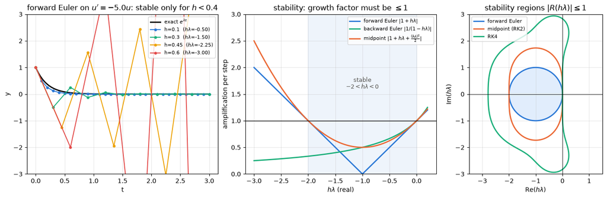

```python
import numpy as np
import matplotlib.pyplot as plt

# =============================================================================
# 1. LOCAL RICHARDSON ON ONE EULER STEP  ==  THE MIDPOINT METHOD
#    y_h     = y0 + h f(t0, y0)                          one full step
#    y_{h/2} = ymid + h/2 f(t0+h/2, ymid),  ymid = y0 + h/2 f(t0,y0)    two half steps
#    yhat    = 2 y_{h/2} - y_h  =  y0 + h f(t0 + h/2, ymid)    <-- midpoint!
# =============================================================================
def one_euler(f, t0, y0, h):      return y0 + h * f(t0, y0)
def two_half_eulers(f, t0, y0, h):
    ymid = y0 + h/2 * f(t0, y0)
    return ymid + h/2 * f(t0 + h/2, ymid)
def richardson(f, t0, y0, h):     return 2*two_half_eulers(f, t0, y0, h) - one_euler(f, t0, y0, h)
def midpoint(f, t0, y0, h):
    ymid = y0 + h/2 * f(t0, y0)
    return y0 + h * f(t0 + h/2, ymid)

f = lambda t, y: np.sin(t) * y + t**2            # an arbitrary non-autonomous f
rng = np.random.default_rng(0)
gap = max(abs(richardson(f, t, y, h) - midpoint(f, t, y, h))
          for t, y, h in rng.uniform(0.1, 2.0, (2000, 3)))
print(f"max | 2*y_(h/2) - y_h  -  midpoint |  over 2000 random (t,y,h) = {gap:.2e}   -> identical\n")

# order check on u' = u, u(0) = 1, T = 1
def march(step, h, T=1.0):
    t, y = 0.0, 1.0
    for _ in range(int(round(T/h))): y = step(lambda a, b: b, t, y, h); t += h
    return y
print(f"{'h':>8} {'Euler err':>12} {'rate':>6} {'Richardson/midpoint err':>24} {'rate':>6}")
pe = pr = None
for h in [0.1, 0.05, 0.025, 0.0125, 0.00625]:
    ee = abs(march(one_euler, h) - np.e); er = abs(march(richardson, h) - np.e)
    re = "" if pe is None else f"{np.log2(pe/ee):6.2f}"; rr = "" if pr is None else f"{np.log2(pr/er):6.2f}"
    print(f"{h:>8.5f} {ee:>12.3e} {re:>6} {er:>24.3e} {rr:>6}")
    pe, pr = ee, er

# =============================================================================
# 2. STABILITY: forward Euler on the test equation u' = lambda u
#    y_{n+1} = (1 + h*lambda) y_n   ->   y_n = y0 (1 + h*lambda)^n
#    bounded  <=>  |1 + h*lambda| <= 1   <=>  (real lambda<0)  h <= 2/|lambda|
# =============================================================================
lam, T = -5.0, 3.0
print(f"\ntest equation u' = {lam} u, u(0)=1  ->  stability limit h = 2/|lambda| = {2/abs(lam):.2f}")
print(f"{'h':>7} {'h*lambda':>9} {'|1+h*lam|':>10} {'y(T)':>14} {'exact':>10}  verdict")
for h in [0.1, 0.3, 0.39, 0.4, 0.45, 0.6]:
    n = int(round(T/h)); amp = abs(1 + h*lam); y = (1 + h*lam)**n
    verdict = "stable" if amp < 1 else ("marginal" if abs(amp-1) < 1e-12 else "UNSTABLE")
    print(f"{h:>7.2f} {h*lam:>9.2f} {amp:>10.3f} {y:>14.3e} {np.exp(lam*T):>10.2e}  {verdict}")

# =============================================================================
# 3. FIGURE
# =============================================================================
fig, ax = plt.subplots(1, 3, figsize=(14, 4.3), constrained_layout=True)

# (a) the test equation solved with several h
tt = np.linspace(0, T, 400)
ax[0].plot(tt, np.exp(lam*tt), "k-", lw=2, label=r"exact $e^{\lambda t}$")
for h, c in zip([0.1, 0.3, 0.45, 0.6], ["#2a78d6", "#1baf7a", "#eda100", "#e34948"]):
    n = int(T/h); t = h*np.arange(n+1)
    ax[0].plot(t, (1 + h*lam)**np.arange(n+1), "o-", color=c, ms=3.5, lw=1.4, label=f"h={h}  ($h\\lambda$={h*lam:.2f})")
ax[0].set_ylim(-3, 3); ax[0].set_xlabel("t"); ax[0].set_ylabel("y")
ax[0].set_title(rf"forward Euler on $u'={lam}u$: stable only for $h<{2/abs(lam):.1f}$")
ax[0].legend(fontsize=8); ax[0].grid(alpha=0.3)

# (b) amplification factor |1 + h lambda| for real lambda<0
hl = np.linspace(-3, 0.2, 400)
ax[1].plot(hl, np.abs(1 + hl), color="#2a78d6", lw=2, label=r"forward Euler $|1+h\lambda|$")
ax[1].plot(hl, 1/np.abs(1 - hl), color="#1baf7a", lw=2, label=r"backward Euler $|1/(1-h\lambda)|$")
ax[1].plot(hl, np.abs(1 + hl + hl**2/2), color="#eb6834", lw=2, label=r"midpoint $|1+h\lambda+\frac{(h\lambda)^2}{2}|$")
ax[1].axhline(1, color="k", lw=1); ax[1].axvspan(-2, 0, color="#2a78d6", alpha=0.08)
ax[1].text(-1.0, 1.6, "stable\n$-2<h\\lambda<0$", color="#52514e", ha="center", fontsize=9)
ax[1].set_xlabel(r"$h\lambda$ (real)"); ax[1].set_ylabel("amplification per step")
ax[1].set_ylim(0, 3); ax[1].set_title("stability: growth factor must be $\\leq 1$")
ax[1].legend(fontsize=8); ax[1].grid(alpha=0.3)

# (c) stability regions in the complex h*lambda plane
X, Y = np.meshgrid(np.linspace(-3.5, 1.5, 400), np.linspace(-3, 3, 400))
Z = X + 1j*Y
for R, name, c in [(1 + Z, "forward Euler", "#2a78d6"),
                   (1 + Z + Z**2/2, "midpoint (RK2)", "#eb6834"),
                   (1 + Z + Z**2/2 + Z**3/6 + Z**4/24, "RK4", "#1baf7a")]:
    ax[2].contour(X, Y, np.abs(R), levels=[1], colors=[c], linewidths=2)
    ax[2].plot([], [], color=c, lw=2, label=name)
ax[2].contourf(X, Y, np.abs(1 + Z), levels=[0, 1], colors=["#cde2fb"], alpha=0.6)
ax[2].axhline(0, color="k", lw=0.6); ax[2].axvline(0, color="k", lw=0.6)
ax[2].set_xlabel(r"Re$(h\lambda)$"); ax[2].set_ylabel(r"Im$(h\lambda)$")
ax[2].set_title("stability regions $|R(h\\lambda)|\\leq 1$"); ax[2].set_aspect("equal")
ax[2].legend(fontsize=8, loc="upper left"); ax[2].grid(alpha=0.3)
plt.show()
```

### Example: the decay equation

$$u' = \lambda u, \qquad \lambda = -2.5, \qquad u(0) = u_0 \qquad\Longrightarrow\qquad u(t) = u_0 e^{\lambda t} \ \ \text{(decays to 0)}$$

**Forward Euler** applied to it:

$$y_{n+1} = y_n + h\lambda y_n = (1 + h\lambda)\,y_n \qquad\Longrightarrow\qquad y_n = u_0\,\underbrace{(1 + h\lambda)^n}_{R^n}$$

The number $R = 1 + h\lambda$ is the **amplification factor**: every step multiplies the solution by $R$. The numerical solution stays bounded (and decays, like the true one) exactly when $|R| \le 1$:

$$-1 \;\le\; 1 + h\lambda \;\le\; 1$$

Take the two halves separately:

| half | rearranges to | comment |
| --- | --- | --- |
| $1 + h\lambda \le 1$ | $h\lambda \le 0$ | **automatic** for $h>0,\ \lambda<0$ — no constraint |
| $1 + h\lambda \ge -1$ | $h\lambda \ge -2$ | **this is the real condition** |

From $h\lambda \ge -2$, divide by $\lambda$ — and since $\lambda < 0$ the inequality **flips**:

$$\boxed{\ h \;\le\; \frac{2}{|\lambda|}\ } \qquad\text{for } \lambda = -2.5: \quad h \le \frac{2}{2.5} = 0.8$$

#### Three regimes, not two

The single condition $|R|\le 1$ hides a finer structure:

| range of $h$ | $R = 1+h\lambda$ | numerical solution |
| --- | --- | --- |
| $h < 1/\lvert\lambda\rvert = 0.4$ | $0 < R < 1$ | decays **monotonically** — right shape ✓ |
| $h = 1/\lvert\lambda\rvert$ | $R = 0$ | drops to zero in one step |
| $1/\lvert\lambda\rvert < h < 2/\lvert\lambda\rvert$ | $-1 < R < 0$ | decays but **alternates sign** — stable, wrong shape |
| $h = 2/\lvert\lambda\rvert = 0.8$ | $R = -1$ | oscillates forever, constant amplitude |
| $h > 2/\lvert\lambda\rvert$ | $\lvert R\rvert > 1$ | **grows — unstable** |

**Stability is not accuracy.** At $h = 0.79$ the method is stable, yet $y(6) = 0.82$ while the exact value is $3\times10^{-7}$. Stability only guarantees the error does not explode. For a *useful* answer take $h \lesssim 1/|\lambda|$, so that $R$ stays positive.

#### In the complex plane

Writing $z = h\lambda$, the condition $|1 + z| \le 1$ means $|z - (-1)| \le 1$: the **disk of radius 1 centred at $-1$**, touching the origin. For a real decaying $\lambda$ we walk along the negative real axis and leave the disk at $z = -2$ — which is the condition above.

```
u' = -2.5u,  u(0) = 1.0,  exact u(6.0) = 3.059e-07
stability limit:  h <= 2/|lambda| = 0.8
monotone decay:   h <= 1/|lambda| = 0.4

     h  R = 1+h*lam    |R|         y(T)       error  behaviour
  0.20        0.500   0.50    9.313e-10   3.050e-07  decays monotonically (correct shape)
  0.40        0.000   0.00    0.000e+00   3.059e-07  decays monotonically (correct shape)
  0.60       -0.500   0.50    9.766e-04   9.763e-04  decays, but alternates sign
  0.79       -0.975   0.98    8.167e-01   8.167e-01  decays, but alternates sign
  0.80       -1.000   1.00    1.000e+00   1.000e+00  constant amplitude (marginal)
  0.81       -1.025   1.03   -1.189e+00   1.189e+00  GROWS -> unstable
  1.00       -1.500   1.50    1.139e+01   1.139e+01  GROWS -> unstable
```

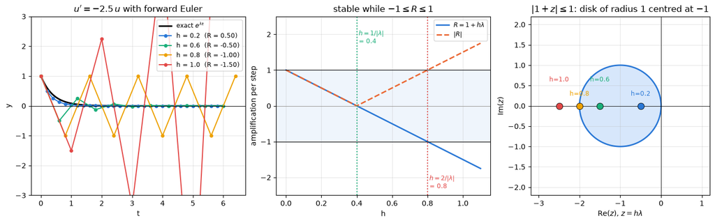

```python
import numpy as np
import matplotlib.pyplot as plt

# =============================================================================
# DECAY EQUATION   u' = lambda*u,  lambda < 0,  u(0) = u0   ->   u = u0*exp(lambda*t)
# Forward Euler:   y_{n+1} = (1 + h*lambda) y_n   =>   y_n = u0*(1 + h*lambda)^n
# Stable  <=>  |1 + h*lambda| <= 1  <=>  h <= 2/|lambda|
# =============================================================================
lam, u0, T = -2.5, 1.0, 6.0
h_max = 2 / abs(lam)                       # = 0.8

def euler(h, T=T):
    n = int(round(T / h))
    t = h * np.arange(n + 1)
    return t, u0 * (1 + h * lam) ** np.arange(n + 1)   # closed form of the recursion

def exact(t):
    return u0 * np.exp(lam * t)

print(f"u' = {lam}u,  u(0) = {u0},  exact u({T}) = {exact(T):.3e}")
print(f"stability limit:  h <= 2/|lambda| = {h_max}")
print(f"monotone decay:   h <= 1/|lambda| = {1/abs(lam)}\n")
print(f"{'h':>6} {'R = 1+h*lam':>12} {'|R|':>6} {'y(T)':>12} {'error':>11}  behaviour")
for h in [0.2, 0.4, 0.6, 0.79, 0.8, 0.81, 1.0]:
    R = 1 + h * lam
    t, y = euler(h)
    if abs(R) > 1:      beh = "GROWS -> unstable"
    elif abs(R) == 1:   beh = "constant amplitude (marginal)"
    elif R < 0:         beh = "decays, but alternates sign"
    else:               beh = "decays monotonically (correct shape)"
    print(f"{h:>6.2f} {R:>12.3f} {abs(R):>6.2f} {y[-1]:>12.3e} {abs(y[-1]-exact(T)):>11.3e}  {beh}")

# ---- the same information as a picture -------------------------------------
fig, ax = plt.subplots(1, 3, figsize=(14, 4.2), constrained_layout=True)
tt = np.linspace(0, T, 500)

# (a) solutions for several h
ax[0].plot(tt, exact(tt), "k-", lw=2.2, label=r"exact $e^{\lambda t}$")
for h, c in zip([0.2, 0.6, 0.8, 1.0], ["#2a78d6", "#1baf7a", "#eda100", "#e34948"]):
    t, y = euler(h)
    ax[0].plot(t, y, "o-", color=c, ms=4, lw=1.5, label=f"h = {h}  (R = {1+h*lam:.2f})")
ax[0].axhline(0, color="k", lw=0.7)
ax[0].set_ylim(-3, 3); ax[0].set_xlabel("t"); ax[0].set_ylabel("y")
ax[0].set_title(rf"$u' = {lam}\,u$ with forward Euler")
ax[0].legend(fontsize=8.5); ax[0].grid(alpha=0.3)

# (b) the amplification factor R(h) and the three regimes
hh = np.linspace(0, 1.1, 400)
R = 1 + hh * lam
ax[1].plot(hh, R, color="#2a78d6", lw=2, label=r"$R = 1 + h\lambda$")
ax[1].plot(hh, np.abs(R), color="#eb6834", lw=2, ls="--", label=r"$|R|$")
ax[1].axhspan(-1, 1, color="#2a78d6", alpha=0.07)
ax[1].axhline(1, color="k", lw=0.8); ax[1].axhline(-1, color="k", lw=0.8); ax[1].axhline(0, color="#8a8984", lw=0.6)
ax[1].axvline(1/abs(lam), color="#1baf7a", ls=":", lw=1.5)
ax[1].axvline(h_max, color="#e34948", ls=":", lw=1.5)
ax[1].text(1/abs(lam), 1.75, f" $h=1/|\\lambda|$\n = {1/abs(lam)}", color="#1baf7a", fontsize=8.5)
ax[1].text(h_max, -2.3, f" $h=2/|\\lambda|$\n = {h_max}", color="#e34948", fontsize=8.5)
ax[1].set_ylim(-2.5, 2.5); ax[1].set_xlabel("h"); ax[1].set_ylabel("amplification per step")
ax[1].set_title("stable while $-1 \\leq R \\leq 1$"); ax[1].legend(fontsize=8.5); ax[1].grid(alpha=0.3)

# (c) stability region in the complex plane, with our z = h*lambda marked
X, Y = np.meshgrid(np.linspace(-3.2, 1.2, 400), np.linspace(-2.2, 2.2, 400))
Z = X + 1j*Y
ax[2].contourf(X, Y, np.abs(1 + Z), levels=[0, 1], colors=["#cde2fb"], alpha=0.8)
ax[2].contour(X, Y, np.abs(1 + Z), levels=[1], colors=["#2a78d6"], linewidths=2)
ax[2].axhline(0, color="k", lw=0.6); ax[2].axvline(0, color="k", lw=0.6)
for h, c in zip([0.2, 0.6, 0.8, 1.0], ["#2a78d6", "#1baf7a", "#eda100", "#e34948"]):
    ax[2].plot(h*lam, 0, "o", color=c, ms=9, mec="k", mew=0.6, zorder=5)
    ax[2].annotate(f"h={h}", (h*lam, 0), (h*lam, 0.25 + 0.35*(h in (0.6, 1.0))),
                   ha="center", fontsize=8.5, color=c)
ax[2].set_xlabel(r"Re$(z)$, $z = h\lambda$"); ax[2].set_ylabel(r"Im$(z)$")
ax[2].set_title(r"$|1+z| \leq 1$: disk of radius 1 centred at $-1$")
ax[2].set_aspect("equal"); ax[2].grid(alpha=0.3)
plt.show()
```

# Day 3 — Runge–Kutta methods

### One-step methods

$$y_{n+1} = y_n + h\,\Phi(t_n, y_n, h)$$

$\Phi$ is the **increment function** — it produces *one* slope to advance the whole step. Different choices of $\Phi$ give different methods:

| method | $\Phi$ | order |
| --- | --- | --- |
| Euler | $f(t_n, y_n)$ | 1 |
| Heun | $\tfrac12\big(f(t_n,y_n) + f(t_{n+1}, \tilde y_{n+1})\big)$ | 2 |
| midpoint | $f\big(t_n+\tfrac h2,\ y_n + \tfrac h2 f(t_n,y_n)\big)$ | 2 |

### Method of Heun (predictor–corrector)

Euler uses the slope at the *left end* only, which is why it lags. Heun takes the average of the slopes at **both ends** — but the slope at the right end needs a value there, which we don't have yet. So: predict it with Euler, then correct.

$$\textbf{1. Predictor (Euler):}\qquad \tilde y_{n+1} = y_n + h\,f(t_n, y_n)$$ $$\textbf{2. Evaluate the slope there:}\qquad f(t_{n+1},\ \tilde y_{n+1})$$ $$\textbf{3. Corrector (trapezoid):}\qquad y_{n+1} = y_n + \frac{h}{2}\Big(f(t_n,y_n) + f(t_{n+1},\tilde y_{n+1})\Big)$$

Cost: **2 evaluations of $f$** per step, order **2**. (Compare: Euler is 1 evaluation, order 1.)

### General Runge–Kutta form

Both are special cases of an $s$-stage explicit Runge–Kutta method:

$$k_i = f\Big(t_n + c_i h,\ y_n + h\sum_{j<i} a_{ij}k_j\Big), \qquad y_{n+1} = y_n + h\sum_{i=1}^{s} b_i k_i$$

The coefficients are collected in a **Butcher tableau**:

$$\begin{array}{c|c} \mathbf{c} & A \\ \hline & \mathbf{b}^T \end{array} \qquad \underbrace{\begin{array}{c|c} 0 & \\ \hline & 1\end{array}}_{\text{Euler}} \qquad \underbrace{\begin{array}{c|cc} 0 & & \\ 1 & 1 & \\ \hline & \frac12 & \frac12\end{array}}_{\text{Heun}} \qquad \underbrace{\begin{array}{c|cc} 0 & & \\ \frac12 & \frac12 & \\ \hline & 0 & 1\end{array}}_{\text{midpoint}} \qquad \underbrace{\begin{array}{c|cccc} 0 & & & & \\ \frac12 & \frac12 & & & \\ \frac12 & 0 & \frac12 & & \\ 1 & 0 & 0 & 1 & \\ \hline & \frac16 & \frac13 & \frac13 & \frac16\end{array}}_{\text{RK4}}$$

**Heun and midpoint are both RK2** — same order, different tableaux. Heun samples the two *ends*; midpoint samples the *middle*. (And midpoint is exactly what local Richardson extrapolation of Euler produces.)

> **Consistency condition:** $\sum_i b_i = 1$ — the weights must average, not scale. Check: Euler $1$; Heun $\frac12+\frac12$; RK4 $\frac16+\frac13+\frac13+\frac16 = 1$. ✓

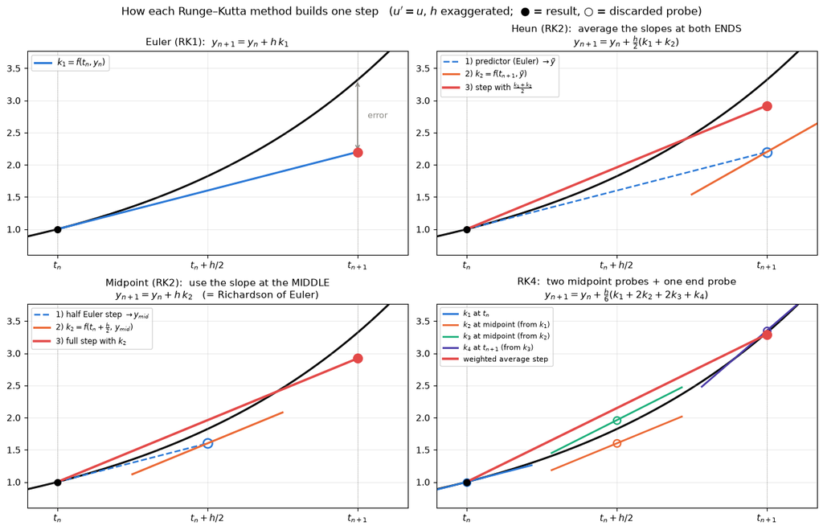

```
one step with h = 1.2, exact e^h = 3.32012
  Euler     y_1 = 2.20000   error = 1.12e+00
  Heun      y_1 = 2.92000   error = 4.00e-01
  midpoint  y_1 = 2.92000   error = 4.00e-01
  RK4       y_1 = 3.29440   error = 2.57e-02
```

```python
import numpy as np
import matplotlib.pyplot as plt

# test problem with visible curvature so the stages differ:  u' = u,  u(0) = 1
f      = lambda t, y: y
exact  = lambda t: np.exp(t)
t0, y0, h = 0.0, 1.0, 1.2                      # big h on purpose, so the geometry is visible

C = dict(exact="#0b0b0b", k1="#2a78d6", k2="#eb6834", k3="#1baf7a", k4="#4a3aa7",
         step="#e34948", ghost="#8a8984")

def slope_seg(ax, t, y, s, half=0.30, **kw):
    """draw a short line of slope s through (t,y)"""
    ax.plot([t - half, t + half], [y - half*s, y + half*s], **kw)

def frame(ax, title):
    tt = np.linspace(t0 - 0.12, t0 + h + 0.2, 200)
    ax.plot(tt, exact(tt), color=C["exact"], lw=2.2, zorder=1)
    ax.plot(t0, y0, "o", color="k", ms=7, zorder=6)
    ax.axvline(t0, color=C["ghost"], lw=0.6, ls=":"); ax.axvline(t0+h, color=C["ghost"], lw=0.6, ls=":")
    ax.set_title(title, fontsize=11)
    ax.set_xticks([t0, t0+h/2, t0+h]); ax.set_xticklabels(["$t_n$", "$t_n+h/2$", "$t_{n+1}$"])
    ax.set_xlim(t0-0.12, t0+h+0.2); ax.set_ylim(0.6, exact(h)+0.45); ax.grid(alpha=0.25)

fig, ax = plt.subplots(2, 2, figsize=(12.5, 8), constrained_layout=True)
fig.suptitle("How each Runge–Kutta method builds one step   ($u'=u$, $h$ exaggerated;  ● = result, ○ = discarded probe)", fontsize=12)

# ---------------------------------------------------------------- 1. EULER
a = ax[0,0]; frame(a, "Euler (RK1):  $y_{n+1} = y_n + h\\,k_1$")
k1 = f(t0, y0)
a.plot([t0, t0+h], [y0, y0 + h*k1], color=C["k1"], lw=2.2, label=r"$k_1 = f(t_n, y_n)$")
a.plot(t0+h, y0 + h*k1, "o", color=C["step"], ms=10, zorder=6)
a.annotate("", xy=(t0+h, exact(h)), xytext=(t0+h, y0+h*k1),
           arrowprops=dict(arrowstyle="<->", color=C["ghost"], lw=1.2))
a.text(t0+h+0.04, (exact(h)+y0+h*k1)/2, "error", color=C["ghost"], fontsize=9, va="center")
a.legend(fontsize=9, loc="upper left")

# ---------------------------------------------------------------- 2. HEUN
a = ax[0,1]; frame(a, "Heun (RK2):  average the slopes at both ENDS\n$y_{n+1} = y_n + \\frac{h}{2}(k_1 + k_2)$")
y_pred = y0 + h*k1
k2 = f(t0+h, y_pred)
a.plot([t0, t0+h], [y0, y_pred], color=C["k1"], lw=1.8, ls="--", label=r"1) predictor (Euler) $\rightarrow \tilde{y}$")
a.plot(t0+h, y_pred, "o", mfc="none", mec=C["k1"], ms=10, mew=1.8)
slope_seg(a, t0+h, y_pred, k2, color=C["k2"], lw=2.2, label=r"2) $k_2 = f(t_{n+1}, \tilde{y})$")
y_heun = y0 + h/2*(k1 + k2)
a.plot([t0, t0+h], [y0, y_heun], color=C["step"], lw=2.6, label=r"3) step with $\frac{k_1+k_2}{2}$")
a.plot(t0+h, y_heun, "o", color=C["step"], ms=10, zorder=6)
a.legend(fontsize=8.5, loc="upper left")

# ---------------------------------------------------------------- 3. MIDPOINT
a = ax[1,0]; frame(a, "Midpoint (RK2):  use the slope at the MIDDLE\n$y_{n+1} = y_n + h\\,k_2$   (= Richardson of Euler)")
y_mid = y0 + h/2*k1
k2m = f(t0+h/2, y_mid)
a.plot([t0, t0+h/2], [y0, y_mid], color=C["k1"], lw=1.8, ls="--", label=r"1) half Euler step $\rightarrow y_{mid}$")
a.plot(t0+h/2, y_mid, "o", mfc="none", mec=C["k1"], ms=10, mew=1.8)
slope_seg(a, t0+h/2, y_mid, k2m, color=C["k2"], lw=2.2, label=r"2) $k_2 = f(t_n+\frac{h}{2},\, y_{mid})$")
y_mp = y0 + h*k2m
a.plot([t0, t0+h], [y0, y_mp], color=C["step"], lw=2.6, label=r"3) full step with $k_2$")
a.plot(t0+h, y_mp, "o", color=C["step"], ms=10, zorder=6)
a.legend(fontsize=8.5, loc="upper left")

# ---------------------------------------------------------------- 4. RK4
a = ax[1,1]; frame(a, "RK4:  two midpoint probes + one end probe\n$y_{n+1} = y_n + \\frac{h}{6}(k_1 + 2k_2 + 2k_3 + k_4)$")
K1 = f(t0, y0)
Y2 = y0 + h/2*K1;   K2 = f(t0+h/2, Y2)
Y3 = y0 + h/2*K2;   K3 = f(t0+h/2, Y3)
Y4 = y0 + h*K3;     K4 = f(t0+h,   Y4)
for (tp, yp, k, col, lab) in [(t0, y0, K1, "k1", r"$k_1$ at $t_n$"),
                              (t0+h/2, Y2, K2, "k2", r"$k_2$ at midpoint (from $k_1$)"),
                              (t0+h/2, Y3, K3, "k3", r"$k_3$ at midpoint (from $k_2$)"),
                              (t0+h,  Y4, K4, "k4", r"$k_4$ at $t_{n+1}$ (from $k_3$)")]:
    slope_seg(a, tp, yp, k, half=0.26, color=C[col], lw=2, label=lab)
    a.plot(tp, yp, "o", mfc="none", mec=C[col], ms=8, mew=1.6)
y_rk4 = y0 + h/6*(K1 + 2*K2 + 2*K3 + K4)
a.plot([t0, t0+h], [y0, y_rk4], color=C["step"], lw=2.6, label="weighted average step")
a.plot(t0+h, y_rk4, "o", color=C["step"], ms=10, zorder=6)
a.legend(fontsize=8, loc="upper left")
plt.show()

print(f"one step with h = {h}, exact e^h = {exact(h):.5f}")
for n, v in [("Euler", y0+h*k1), ("Heun", y_heun), ("midpoint", y_mp), ("RK4", y_rk4)]:
    print(f"  {n:<9} y_1 = {v:.5f}   error = {abs(v-exact(h)):.2e}")
```

```
max | Heun by hand - Heun from tableau | over 2000 random (t,y,h) = 0.00e+00

       h               Euler (RK1)                Heun (RK2)            midpoint (RK2)                       RK4
                error         rate        error         rate        error         rate        error         rate
  0.2000     2.30e-01                  1.56e-02                  1.56e-02                  3.07e-05
  0.1000     1.25e-01         0.88     4.20e-03         1.89     4.20e-03         1.89     2.08e-06         3.88
  0.0500     6.50e-02         0.94     1.09e-03         1.95     1.09e-03         1.95     1.36e-07         3.94
  0.0250     3.32e-02         0.97     2.78e-04         1.97     2.78e-04         1.97     8.67e-09         3.97
  0.0125     1.68e-02         0.98     7.01e-05         1.99     7.01e-05         1.99     5.47e-10         3.98

expected orders: {'Euler (RK1)': 1, 'Heun (RK2)': 2, 'midpoint (RK2)': 2, 'RK4': 4}
f-evaluations per step: {'Euler (RK1)': 1, 'Heun (RK2)': 2, 'midpoint (RK2)': 2, 'RK4': 4}
```

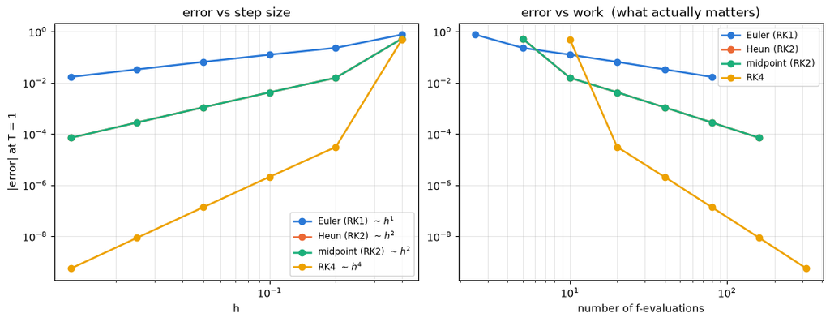

```python
import numpy as np
import matplotlib.pyplot as plt

# =============================================================================
# General explicit one-step method:   y_{n+1} = y_n + h * Phi(t_n, y_n, h)
# Runge-Kutta: Phi is built from s stage slopes k_i, described by a Butcher tableau
#     k_i = f(t_n + c_i*h,  y_n + h * sum_j a_ij k_j)      (explicit: j < i)
#     Phi = sum_i b_i k_i
# =============================================================================
def rk_step(f, t, y, h, A, b, c):
    s = len(b); k = []
    for i in range(s):
        yi = y + h * sum(A[i][j] * k[j] for j in range(i)) if i else y
        k.append(f(t + c[i]*h, yi))
    return y + h * sum(b[i]*k[i] for i in range(s))

# --- the tableaux ------------------------------------------------------------
EULER    = ([[0]], [1.0], [0.0])                                    # order 1
HEUN     = ([[0,0],[1,0]], [0.5, 0.5], [0.0, 1.0])                  # order 2  (trapezoid)
MIDPOINT = ([[0,0],[0.5,0]], [0.0, 1.0], [0.0, 0.5])                # order 2  (= Richardson of Euler)
RK4      = ([[0,0,0,0],[0.5,0,0,0],[0,0.5,0,0],[0,0,1,0]],
            [1/6, 1/3, 1/3, 1/6], [0.0, 0.5, 0.5, 1.0])             # order 4
METHODS = {"Euler (RK1)": (EULER, 1, "#2a78d6"), "Heun (RK2)": (HEUN, 2, "#eb6834"),
           "midpoint (RK2)": (MIDPOINT, 2, "#1baf7a"), "RK4": (RK4, 4, "#eda100")}

# --- Heun written out by hand == Heun from the tableau -----------------------
def heun_by_hand(f, t0, y0, h):
    y_pred = y0 + h * f(t0, y0)                        # predictor: one Euler step
    return y0 + h/2 * (f(t0, y0) + f(t0 + h, y_pred))  # corrector: average the two slopes

g = lambda t, y: np.sin(t)*y + t**2
rng = np.random.default_rng(0)
gap = max(abs(heun_by_hand(g, t, y, h) - rk_step(g, t, y, h, *HEUN))
          for t, y, h in rng.uniform(0.1, 2.0, (2000, 3)))
print(f"max | Heun by hand - Heun from tableau | over 2000 random (t,y,h) = {gap:.2e}\n")

# --- order verification on u' = u, u(0) = 1, T = 1 ---------------------------
f = lambda t, y: y
def march(tab, h, T=1.0):
    t, y = 0.0, 1.0
    for _ in range(int(round(T/h))): y = rk_step(f, t, y, h, *tab); t += h
    return y

print(f"{'h':>8}" + "".join(f"{n:>26}" for n in METHODS))
print(f"{'':>8}" + "".join(f"{'error':>13}{'rate':>13}" for _ in METHODS))
prev = {n: None for n in METHODS}
for h in [0.2, 0.1, 0.05, 0.025, 0.0125]:
    row = f"{h:>8.4f}"
    for n, (tab, p, _) in METHODS.items():
        e = abs(march(tab, h) - np.e)
        r = "" if prev[n] is None else f"{np.log2(prev[n]/e):13.2f}"
        row += f"{e:>13.2e}{r:>13}"; prev[n] = e
    print(row)
print("\nexpected orders:", {n: p for n, (_, p, _) in METHODS.items()})
print("f-evaluations per step:", {n: len(tab[1]) for n, (tab, _, _) in METHODS.items()})

# --- figure: accuracy per step AND per f-evaluation --------------------------
fig, ax = plt.subplots(1, 2, figsize=(11, 4.2), constrained_layout=True)
hs = np.array([0.4, 0.2, 0.1, 0.05, 0.025, 0.0125])
for n, (tab, p, c) in METHODS.items():
    errs = np.array([abs(march(tab, h) - np.e) for h in hs])
    ax[0].loglog(hs, errs, "o-", color=c, lw=1.8, label=f"{n}  ~ $h^{p}$")
    ax[1].loglog(len(tab[1])/hs, errs, "o-", color=c, lw=1.8, label=n)   # cost = s * (1/h) evaluations
ax[0].set_xlabel("h"); ax[0].set_ylabel("|error| at T = 1"); ax[0].set_title("error vs step size")
ax[1].set_xlabel("number of f-evaluations"); ax[1].set_title("error vs work  (what actually matters)")
for a in ax: a.legend(fontsize=8.5); a.grid(alpha=0.3, which="both"); a.xaxis.set_minor_formatter(plt.NullFormatter())
plt.show()
```